# EGRMGMT 590.21 Homework 5 (Questions)

### Exercise 6 (10 Points)

- Use brand.df to aggregate the average rating of each adjective by brand
- Standardize the average rating data and save the standardized data to a new dataframe named brand.mean.sc
- Conduct PCA for brand.mean.sc and create a scree plot (i.e. variance by principal component)
- Based on the scree plot, what is the appropriate number of principal components?

```r
brand.aggregate<-aggregate(.~Brand, data = brand.df, mean)
brand.aggregate
```

```
##    Brand Adaptable BestValue CuttingEdge Delightful Exciting Friendly
## 1   Papa  4.400000  3.708889    3.473333   3.528889 3.382222 4.686667
## 2  Romeo  4.304089  3.815162    3.912266   3.931005 3.764906 4.373935
## 3 Sierra  4.172475  3.873101    4.305630   4.108132 4.084004 4.051832
## 4  Tango  4.159609  4.091205    4.693811   4.387622 4.429967 3.817590
##   Generous  Helpful Intuitive
## 1 3.762222 4.364444  4.182222
## 2 3.948893 3.988927  3.875639
## 3 4.137623 3.719392  3.525469
## 4 4.355049 3.475570  3.198697
```

```r
brand.mean.sc<-scale(brand.aggregate[,-1])
pca.brand.mean.sc<-prcomp(brand.mean.sc)
summary(prcomp(brand.mean.sc))
```

```
## Importance of components:
##                           PC1     PC2     PC3      PC4
## Standard deviation     2.9707 0.38758 0.15777 2.04e-16
## Proportion of Variance 0.9805 0.01669 0.00277 0.00e+00
## Cumulative Proportion  0.9805 0.99723 1.00000 1.00e+00
```

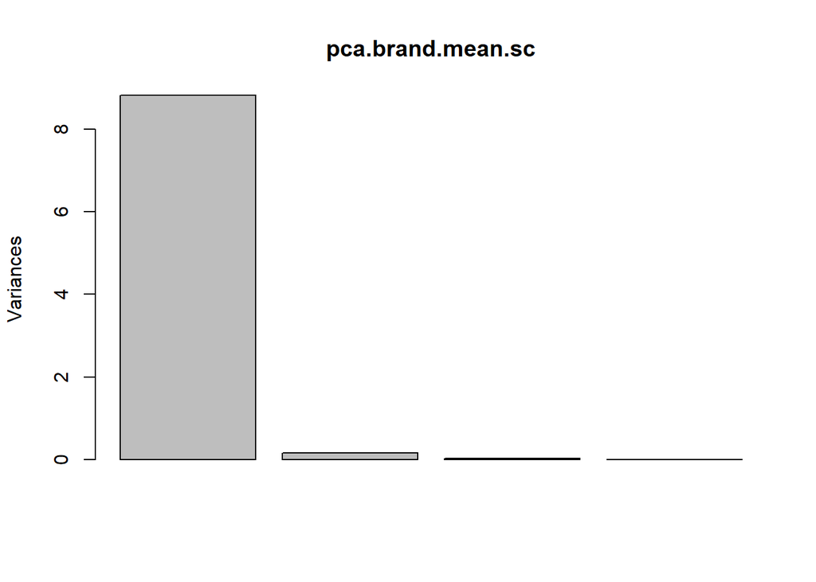

```r
screeplot(pca.brand.mean.sc)
```

```r
##we infer from the screepolt that there should be only 1 pca
```

### Exercise 7 (10 Points)

- Use biplot() to create a perceptual map using the first two principal components resulted from the PCA in Exercise 6
- Based on the perceptual map, what areas did the brand Papa overperform relative to other brands?

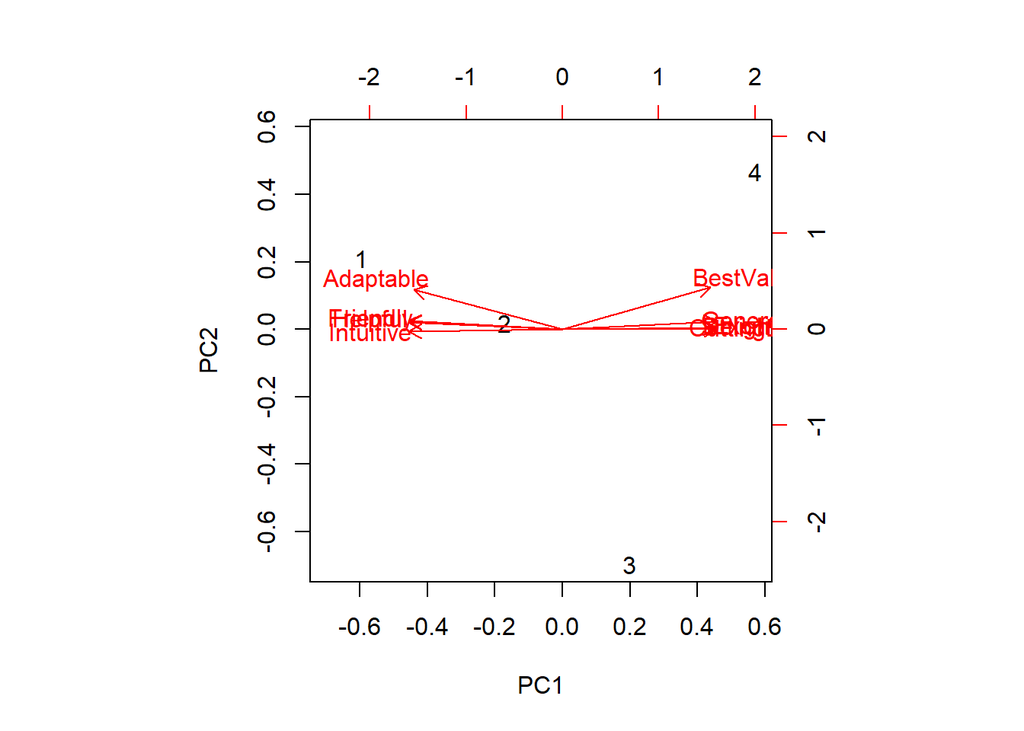

```r
biplot(pca.brand.mean.sc)
```

```r
####we observe from the plot that brand papa is better than other is in the areas Friendly ,adaptable ,intuitive and helpful
```

### Exercise 8 (10 Points)

- Conduct an exploratory factor analysis (EFA) with an appropriate number of factors for the data in brand.sc
- Explain why you select the specific number of factors for the EFA

```r
library(nFactors)
nScree(brand.sc[, 1:9])
```

```
##   noc naf nparallel nkaiser
## 1   0   3         3       3
```

```r
q8.df<-factanal(brand.sc[,1:9], factor=3)
q8.df
```

```
##
## Call:
## factanal(x = brand.sc[, 1:9], factors = 3)
##
## Uniquenesses:
##   Adaptable   BestValue CuttingEdge  Delightful    Exciting    Friendly
##       0.706       0.005       0.579       0.752       0.646       0.671
##    Generous     Helpful   Intuitive
##       0.859       0.699       0.506
##
## Loadings:
##             Factor1 Factor2 Factor3
## Adaptable    0.372           0.394
## BestValue                    0.997
## CuttingEdge          0.648
## Delightful           0.498
## Exciting             0.595
## Friendly     0.573
## Generous             0.376
## Helpful      0.548
## Intuitive    0.702
##
##                Factor1 Factor2 Factor3
## SS loadings      1.262   1.164   1.152
## Proportion Var   0.140   0.129   0.128
## Cumulative Var   0.140   0.270   0.398
##
## Test of the hypothesis that 3 factors are sufficient.
## The chi square statistic is 11.99 on 12 degrees of freedom.
## The p-value is 0.446
```

```r
###we observe from the nscree function that efa must be 3.when we do it with 2 factors p value is low and with 3 p is high so null must fly. Hence 3 is the best possible solution for this
```

[output not shown]

### Exercise 9 (10 Points)

- Use the heatmap.2() function in the gplots library to create a heatmap of factor loadings for brand adjectives based on the output of Exercise 8

```r
e9<-factanal(brand.sc[-10],factors = 3)
e9
```

```
##
## Call:
## factanal(x = brand.sc[-10], factors = 3)
##
## Uniquenesses:
##   Adaptable   BestValue CuttingEdge  Delightful    Exciting    Friendly
##       0.706       0.005       0.579       0.752       0.646       0.671
##    Generous     Helpful   Intuitive
##       0.859       0.699       0.506
##
## Loadings:
##             Factor1 Factor2 Factor3
## Adaptable    0.372           0.394
## BestValue                    0.997
## CuttingEdge          0.648
## Delightful           0.498
## Exciting             0.595
## Friendly     0.573
## Generous             0.376
## Helpful      0.548
## Intuitive    0.702
##
##                Factor1 Factor2 Factor3
## SS loadings      1.262   1.164   1.152
## Proportion Var   0.140   0.129   0.128
## Cumulative Var   0.140   0.270   0.398
##
## Test of the hypothesis that 3 factors are sufficient.
## The chi square statistic is 11.99 on 12 degrees of freedom.
## The p-value is 0.446
```

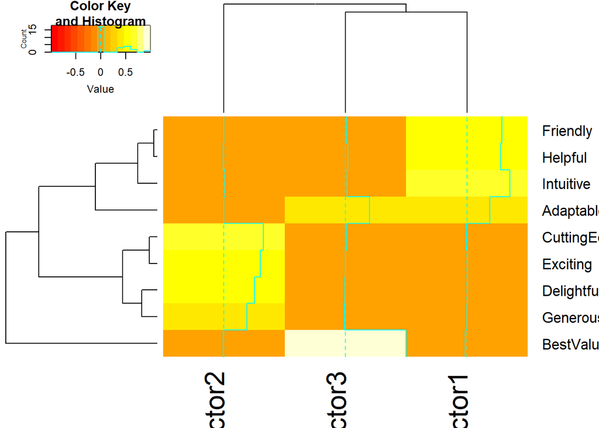

```r
library(gplots)
heatmap.2(loadings(q8.df))
```

### Exercise 10 (10 Points)

- Create a multidimensional scaling (MDS) map for the brands using the data in brand.mean.sc
- Based on the MDS map, which brand is Papa most similar to?
- [Hint] Use the dist() function to create the distance matrix first and then use the cmdscale() function to create the MDS matrix

```r
q10<-dist(brand.mean.sc)
q10
```

```
##          1        2        3
## 2 2.555438
## 3 4.774816 2.283983
## 4 6.937106 4.429864 2.388965
```

```r
q10a<-cmdscale(q10)
q10a
```

```
##           [,1]        [,2]
## [1,]  3.545479  0.16301551
## [2,]  1.019498  0.01480256
## [3,] -1.176741 -0.54060681
## [4,] -3.388236  0.36278874
```

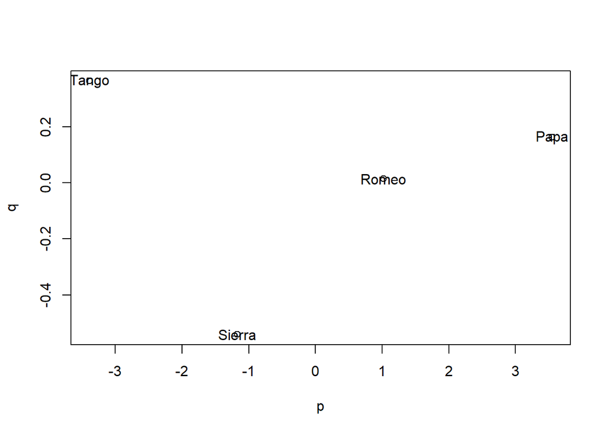

```r
p <- q10a[,1]
q <- q10a[,2]
plot(p,q)
brand.mean.sc<-cbind(brand.mean.sc, brand.aggregate[1])
text(p, q, labels = brand.mean.sc$Brand)
```

```r
##theclosest association is between papa and romeo
```